[figure not shown]

# Finance Data Project

In this data project we will focus on exploratory data analysis of stock prices. Keep in mind, this project is just meant to practice your visualization and pandas skills, it is not meant to be a robust financial analysis or be taken as financial advice.

**NOTE: This project is extremely challenging because it will introduce a lot of new concepts and have you looking things up on your own (we'll point you in the right direction) to try to solve the tasks issued. Feel free to just go through the solutions lecture notebook and video as a "walkthrough" project if you don't want to have to look things up yourself. You'll still learn a lot that way!**

We'll focus on bank stocks and see how they progressed throughout the [financial crisis](https://en.wikipedia.org/wiki/Financial_crisis_of_2007%E2%80%9308) all the way to early 2016.

## Get the Data

In this section we will learn how to use pandas to directly read data from Google finance using pandas!

First we need to start with the proper imports, which we've already laid out for you here.

*Note: [You'll need to install pandas-datareader for this to work!](https://github.com/pydata/pandas-datareader) Pandas datareader allows you to [read stock information directly from the internet](http://pandas.pydata.org/pandas-docs/stable/remote_data.html) Use these links for install guidance (**pip install pandas-datareader**), or just follow along with the video lecture.*

### The Imports

Already filled out for you.

```python
from pandas_datareader import data, wb
import pandas as pd
import numpy as np
import datetime
%matplotlib inline
```

## Data

We need to get data using pandas datareader. We will get stock information for the following banks:

- Bank of America
- CitiGroup
- Goldman Sachs
- JPMorgan Chase
- Morgan Stanley
- Wells Fargo

**Figure out how to get the stock data from Jan 1st 2006 to Jan 1st 2016 for each of these banks. Set each bank to be a separate dataframe, with the variable name for that bank being its ticker symbol. This will involve a few steps:**

1. Use datetime to set start and end datetime objects.
2. Figure out the ticker symbol for each bank.
3. Figure out how to use datareader to grab info on the stock.

**Use [this documentation page](http://pandas.pydata.org/pandas-docs/stable/remote_data.html) for hints and instructions (it should just be a matter of replacing certain values. Use google finance as a source, for example:**

```
# Bank of America
BAC = data.DataReader("BAC", 'google', start, end)
```

```python
start = datetime.datetime(2006, 1, 1)
end = datetime.datetime(2016, 1, 1)
```

```python
df = data.DataReader(['BAC', 'C', 'GS', 'JPM', 'MS', 'WFC'],'yahoo', start, end)  # i've got the linecode from the solved model
```

```python
df.head()
```

| Attributes Symbols Date | Adj Close BAC | Adj Close C | Adj Close GS | Adj Close JPM | Adj Close MS | Adj Close WFC | Close BAC | Close C | Close GS | Close JPM | ... | Open GS | Open JPM | Open MS | Open WFC | Volume BAC | Volume C | Volume GS | Volume JPM | Volume MS | Volume WFC |
| --- | --- | --- | --- | --- | --- | --- | --- | --- | --- | --- | --- | --- | --- | --- | --- | --- | --- | --- | --- | --- | --- |
| 2006-01-03 | 35.298687 | 388.105530 | 106.907135 | 27.529718 | 37.399338 | 20.408512 | 47.080002 | 492.899994 | 128.869995 | 40.189999 | ... | 126.699997 | 39.830002 | 57.169998 | 31.600000 | 16296700.0 | 1537600.0 | 6188700.0 | 12838600.0 | 5377000.0 | 11016400.0 |
| 2006-01-04 | 34.923801 | 380.940277 | 105.430481 | 27.370821 | 37.424999 | 20.171795 | 46.580002 | 483.799988 | 127.089996 | 39.619999 | ... | 127.349998 | 39.779999 | 58.700001 | 31.799999 | 17757900.0 | 1870900.0 | 4861600.0 | 13491500.0 | 7977800.0 | 10870000.0 |
| 2006-01-05 | 34.968796 | 382.830109 | 105.389030 | 27.453718 | 37.527611 | 20.149401 | 46.639999 | 486.200012 | 127.040001 | 39.740002 | ... | 126.000000 | 39.610001 | 58.549999 | 31.500000 | 14970700.0 | 1143100.0 | 3717400.0 | 8109400.0 | 5778000.0 | 10158000.0 |
| 2006-01-06 | 34.916302 | 382.830109 | 106.882248 | 27.647156 | 37.566090 | 20.267757 | 46.570000 | 486.200012 | 128.839996 | 40.020000 | ... | 127.290001 | 39.919998 | 58.770000 | 31.580000 | 12599800.0 | 1370200.0 | 4319600.0 | 7966900.0 | 6889800.0 | 8403800.0 |
| 2006-01-09 | 34.938789 | 381.019043 | 108.168098 | 28.096193 | 37.963749 | 20.264565 | 46.599998 | 483.899994 | 130.389999 | 40.669998 | ... | 128.500000 | 39.880001 | 58.630001 | 31.674999 | 15619400.0 | 1680700.0 | 4723500.0 | 16575200.0 | 4144500.0 | 5619600.0 |

5 rows × 36 columns

**Create a list of the ticker symbols (as strings) in alphabetical order. Call this list: tickers**

```python
tickers = ['BAC', 'C', 'GS', 'JPM', 'MS', 'WFC']
```

**Use pd.concat to concatenate the bank dataframes together to a single data frame called bank_stocks. Set the keys argument equal to the tickers list. Also pay attention to what axis you concatenate on.**

```python
df.columns = df.columns.swaplevel('Attributes', 'Symbols')
bank_stocks = df
```

```python
bank_stocks.head(3)
```

| Symbols Attributes Date | BAC Adj Close | C Adj Close | GS Adj Close | JPM Adj Close | MS Adj Close | WFC Adj Close | BAC Close | C Close | GS Close | JPM Close | ... | GS Open | JPM Open | MS Open | WFC Open | BAC Volume | C Volume | GS Volume | JPM Volume | MS Volume | WFC Volume |
| --- | --- | --- | --- | --- | --- | --- | --- | --- | --- | --- | --- | --- | --- | --- | --- | --- | --- | --- | --- | --- | --- |
| 2006-01-03 | 35.298687 | 388.105530 | 106.907135 | 27.529718 | 37.399338 | 20.408512 | 47.080002 | 492.899994 | 128.869995 | 40.189999 | ... | 126.699997 | 39.830002 | 57.169998 | 31.600000 | 16296700.0 | 1537600.0 | 6188700.0 | 12838600.0 | 5377000.0 | 11016400.0 |
| 2006-01-04 | 34.923801 | 380.940277 | 105.430481 | 27.370821 | 37.424999 | 20.171795 | 46.580002 | 483.799988 | 127.089996 | 39.619999 | ... | 127.349998 | 39.779999 | 58.700001 | 31.799999 | 17757900.0 | 1870900.0 | 4861600.0 | 13491500.0 | 7977800.0 | 10870000.0 |
| 2006-01-05 | 34.968796 | 382.830109 | 105.389030 | 27.453718 | 37.527611 | 20.149401 | 46.639999 | 486.200012 | 127.040001 | 39.740002 | ... | 126.000000 | 39.610001 | 58.549999 | 31.500000 | 14970700.0 | 1143100.0 | 3717400.0 | 8109400.0 | 5778000.0 | 10158000.0 |

3 rows × 36 columns

```python
bank_stocks.columns.names
```

```
FrozenList(['Symbols', 'Attributes'])
```

**Set the column name levels (this is filled out for you):**

```python
bank_stocks.columns.names = ['Bank Ticker','Stock Info']
```

```python
bank_stocks.columns.names
```

```
FrozenList(['Bank Ticker', 'Stock Info'])
```

**Check the head of the bank_stocks dataframe.**

```python
bank_stocks.head(5)
```

| Bank Ticker Stock Info Date | BAC Adj Close | C Adj Close | GS Adj Close | JPM Adj Close | MS Adj Close | WFC Adj Close | BAC Close | C Close | GS Close | JPM Close | ... | GS Open | JPM Open | MS Open | WFC Open | BAC Volume | C Volume | GS Volume | JPM Volume | MS Volume | WFC Volume |
| --- | --- | --- | --- | --- | --- | --- | --- | --- | --- | --- | --- | --- | --- | --- | --- | --- | --- | --- | --- | --- | --- |
| 2006-01-03 | 35.298687 | 388.105530 | 106.907135 | 27.529718 | 37.399338 | 20.408512 | 47.080002 | 492.899994 | 128.869995 | 40.189999 | ... | 126.699997 | 39.830002 | 57.169998 | 31.600000 | 16296700.0 | 1537600.0 | 6188700.0 | 12838600.0 | 5377000.0 | 11016400.0 |
| 2006-01-04 | 34.923801 | 380.940277 | 105.430481 | 27.370821 | 37.424999 | 20.171795 | 46.580002 | 483.799988 | 127.089996 | 39.619999 | ... | 127.349998 | 39.779999 | 58.700001 | 31.799999 | 17757900.0 | 1870900.0 | 4861600.0 | 13491500.0 | 7977800.0 | 10870000.0 |
| 2006-01-05 | 34.968796 | 382.830109 | 105.389030 | 27.453718 | 37.527611 | 20.149401 | 46.639999 | 486.200012 | 127.040001 | 39.740002 | ... | 126.000000 | 39.610001 | 58.549999 | 31.500000 | 14970700.0 | 1143100.0 | 3717400.0 | 8109400.0 | 5778000.0 | 10158000.0 |
| 2006-01-06 | 34.916302 | 382.830109 | 106.882248 | 27.647156 | 37.566090 | 20.267757 | 46.570000 | 486.200012 | 128.839996 | 40.020000 | ... | 127.290001 | 39.919998 | 58.770000 | 31.580000 | 12599800.0 | 1370200.0 | 4319600.0 | 7966900.0 | 6889800.0 | 8403800.0 |
| 2006-01-09 | 34.938789 | 381.019043 | 108.168098 | 28.096193 | 37.963749 | 20.264565 | 46.599998 | 483.899994 | 130.389999 | 40.669998 | ... | 128.500000 | 39.880001 | 58.630001 | 31.674999 | 15619400.0 | 1680700.0 | 4723500.0 | 16575200.0 | 4144500.0 | 5619600.0 |

5 rows × 36 columns

```python
bank_stocks.sort_index(axis=1, level='Bank Ticker', inplace=True)
```

```python
bank_stocks.head(2)
```

| Bank Ticker Stock Info Date | BAC Adj Close | BAC Close | BAC High | BAC Low | BAC Open | BAC Volume | C Adj Close | C Close | C High | C Low | ... | MS High | MS Low | MS Open | MS Volume | WFC Adj Close | WFC Close | WFC High | WFC Low | WFC Open | WFC Volume |
| --- | --- | --- | --- | --- | --- | --- | --- | --- | --- | --- | --- | --- | --- | --- | --- | --- | --- | --- | --- | --- | --- |
| 2006-01-03 | 35.298687 | 47.080002 | 47.180000 | 46.150002 | 46.919998 | 16296700.0 | 388.105530 | 492.899994 | 493.799988 | 481.100006 | ... | 58.490002 | 56.740002 | 57.169998 | 5377000.0 | 20.408512 | 31.900000 | 31.975 | 31.195 | 31.600000 | 11016400.0 |
| 2006-01-04 | 34.923801 | 46.580002 | 47.240002 | 46.450001 | 47.000000 | 17757900.0 | 380.940277 | 483.799988 | 491.000000 | 483.500000 | ... | 59.279999 | 58.349998 | 58.700001 | 7977800.0 | 20.171795 | 31.530001 | 31.820 | 31.365 | 31.799999 | 10870000.0 |

2 rows × 36 columns

# EDA

Let's explore the data a bit! Before continuing, I encourage you to check out the documentation on [Multi-Level Indexing](http://pandas.pydata.org/pandas-docs/stable/advanced.html) and [Using .xs](http://pandas.pydata.org/pandas-docs/stable/generated/pandas.DataFrame.xs.html). Reference the solutions if you can not figure out how to use .xs(), since that will be a major part of this project.

**What is the max Close price for each bank's stock throughout the time period?**

```python
bank_stocks.loc[:,(tickers, slice('Close','Close'))].max()
```

```
Bank Ticker  Stock Info
BAC          Close          54.900002
C            Close         564.099976
GS           Close         247.919998
JPM          Close          70.080002
MS           Close          89.300003
WFC          Close          58.520000
dtype: float64
```

```python
bank_stocks.xs(key='Close',axis=1,level='Stock Info').max() # i've got the answer from the solved model
```

```
Bank Ticker
BAC     54.900002
C      564.099976
GS     247.919998
JPM     70.080002
MS      89.300003
WFC     58.520000
dtype: float64
```

**Create a new empty DataFrame called returns. This dataframe will contain the returns for each bank's stock. returns are typically defined by:**

$$r_t = \frac{p_t - p_{t-1}}{p_{t-1}} = \frac{p_t}{p_{t-1}} - 1$$

```python
returns = pd.DataFrame()
```

```python
Returns = bank_stocks.loc[:,(tickers, slice('Close','Close'))].pct_change()
Returns.head()
```

| Bank Ticker Stock Info Date | BAC Close | C Close | GS Close | JPM Close | MS Close | WFC Close |
| --- | --- | --- | --- | --- | --- | --- |
| 2006-01-03 | NaN | NaN | NaN | NaN | NaN | NaN |
| 2006-01-04 | -0.010620 | -0.018462 | -0.013812 | -0.014183 | 0.000686 | -0.011599 |
| 2006-01-05 | 0.001288 | 0.004961 | -0.000393 | 0.003029 | 0.002742 | -0.001110 |
| 2006-01-06 | -0.001501 | 0.000000 | 0.014169 | 0.007046 | 0.001025 | 0.005874 |
| 2006-01-09 | 0.000644 | -0.004731 | 0.012030 | 0.016242 | 0.010586 | -0.000158 |

**We can use pandas pct_change() method on the Close column to create a column representing this return value. Create a for loop that goes and for each Bank Stock Ticker creates this returns column and set's it as a column in the returns DataFrame.**

```python
for tick in tickers:
    returns[tick + ' Return'] = bank_stocks[tick]['Close'].pct_change() # i 've got the answer from the solved model
returns.head()
```

| Date | BAC Return | C Return | GS Return | JPM Return | MS Return | WFC Return |
| --- | --- | --- | --- | --- | --- | --- |
| 2006-01-03 | NaN | NaN | NaN | NaN | NaN | NaN |
| 2006-01-04 | -0.010620 | -0.018462 | -0.013812 | -0.014183 | 0.000686 | -0.011599 |
| 2006-01-05 | 0.001288 | 0.004961 | -0.000393 | 0.003029 | 0.002742 | -0.001110 |
| 2006-01-06 | -0.001501 | 0.000000 | 0.014169 | 0.007046 | 0.001025 | 0.005874 |
| 2006-01-09 | 0.000644 | -0.004731 | 0.012030 | 0.016242 | 0.010586 | -0.000158 |

**Create a pairplot using seaborn of the returns dataframe. What stock stands out to you? Can you figure out why?**

```python
import seaborn as sns
%matplotlib inline
sns.set()
```

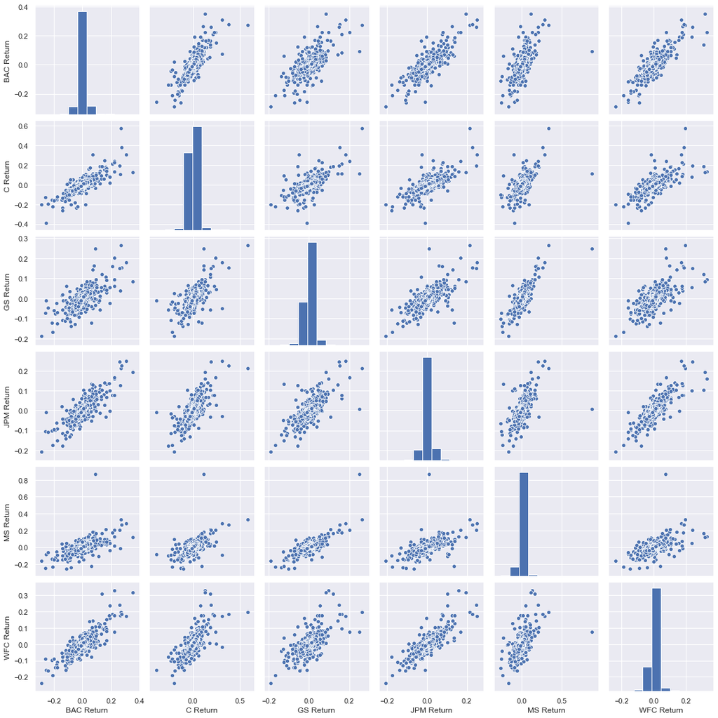

```python
sns.pairplot(returns);
```

- See solution for details about Citigroup behavior....

**Using this returns DataFrame, figure out on what dates each bank stock had the best and worst single day returns. You should notice that 4 of the banks share the same day for the worst drop, did anything significant happen that day?**

```python
Returns.idxmin()
```

```
Bank Ticker  Stock Info
BAC          Close        2009-01-20
C            Close        2009-02-27
GS           Close        2009-01-20
JPM          Close        2009-01-20
MS           Close        2008-10-09
WFC          Close        2009-01-20
dtype: datetime64[ns]
```

```python
returns.idxmin()
```

```
BAC Return   2009-01-20
C Return     2009-02-27
GS Return    2009-01-20
JPM Return   2009-01-20
MS Return    2008-10-09
WFC Return   2009-01-20
dtype: datetime64[ns]
```

```python
returns.at['2009-01-20','BAC Return']
```

```
-0.2896935896149381
```

```python
#returns.loc[(returns.index == '2008-10-09') | (returns.index == '2009-01-20') | (returns.index == '2009-02-27')]
```

**You should have noticed that Citigroup's largest drop and biggest gain were very close to one another, did anythign significant happen in that time frame?**

- See Solution for details

```python
Returns.idxmax()
```

```
Bank Ticker  Stock Info
BAC          Close        2009-04-09
C            Close        2008-11-24
GS           Close        2008-11-24
JPM          Close        2009-01-21
MS           Close        2008-10-13
WFC          Close        2008-07-16
dtype: datetime64[ns]
```

```python
returns.idxmax()
```

```
BAC Return   2009-04-09
C Return     2008-11-24
GS Return    2008-11-24
JPM Return   2009-01-21
MS Return    2008-10-13
WFC Return   2008-07-16
dtype: datetime64[ns]
```

**Take a look at the standard deviation of the returns, which stock would you classify as the riskiest over the entire time period? Which would you classify as the riskiest for the year 2015?**

```python
Returns.std()
```

```
Bank Ticker  Stock Info
BAC          Close         0.036647
C            Close         0.038672
GS           Close         0.025390
JPM          Close         0.027667
MS           Close         0.037819
WFC          Close         0.030238
dtype: float64
```

```python
returns['2006-01-04':].std()
```

```
BAC Return    0.036647
C Return      0.038672
GS Return     0.025390
JPM Return    0.027667
MS Return     0.037819
WFC Return    0.030238
dtype: float64
```

```python
Returns['2015-01-01':'2015-12-31'].std()
```

```
Bank Ticker  Stock Info
BAC          Close         0.016163
C            Close         0.015289
GS           Close         0.014046
JPM          Close         0.014017
MS           Close         0.016249
WFC          Close         0.012591
dtype: float64
```

```python
returns['2015-01-01':'2015-12-31'].std()
```

```
BAC Return    0.016163
C Return      0.015289
GS Return     0.014046
JPM Return    0.014017
MS Return     0.016249
WFC Return    0.012591
dtype: float64
```

**Create a distplot using seaborn of the 2015 returns for Morgan Stanley**

```python
returns.loc['2015-01-01':'2015-12-31','MS Return']
```

```
Date
2015-01-02   -0.002320
2015-01-05   -0.031258
2015-01-06   -0.028800
2015-01-07    0.014278
2015-01-08    0.014889
                ...
2015-12-24   -0.003681
2015-12-28   -0.009544
2015-12-29    0.011812
2015-12-30   -0.009831
2015-12-31   -0.013031
Name: MS Return, Length: 252, dtype: float64
```

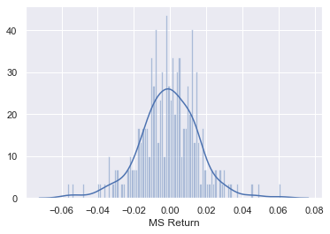

```python
sns.distplot(returns.loc['2015-01-01':'2015-12-31','MS Return'],bins=100);
```

**Create a distplot using seaborn of the 2008 returns for CitiGroup**

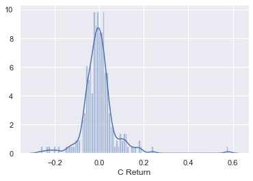

```python
sns.distplot(returns.loc['2008-01-01':'2008-12-31','C Return'],bins=100);
```

# More Visualization

A lot of this project will focus on visualizations. Feel free to use any of your preferred visualization libraries to try to recreate the described plots below, seaborn, matplotlib, plotly and cufflinks, or just pandas.

### Imports

```python
import matplotlib.pyplot as plt
import seaborn as sns
sns.set_style('whitegrid')
%matplotlib inline

# Optional Plotly Method Imports
import plotly
import cufflinks as cf
cf.go_offline()
```

**Create a line plot showing Close price for each bank for the entire index of time. (Hint: Try using a for loop, or use [.xs](http://pandas.pydata.org/pandas-docs/stable/generated/pandas.DataFrame.xs.html) to get a cross section of the data.)**

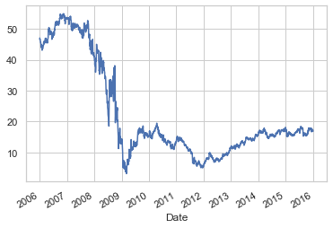

```python
bank_stocks['BAC']['Close'].plot();
```

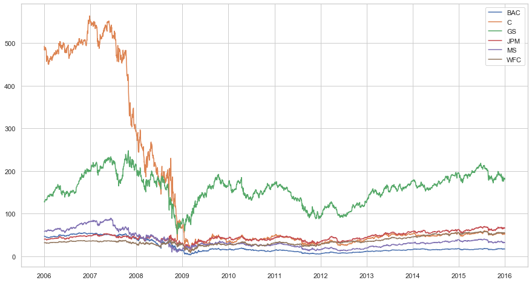

```python
fig, ax = plt.subplots(figsize=(15, 8))
for tick in tickers:
    plt.plot(bank_stocks.index,bank_stocks[tick]['Close'],label=tick);
    plt.legend()
```

```python
#bank_stocks.columns
```

```python
tickers
```

```
['BAC', 'C', 'GS', 'JPM', 'MS', 'WFC']
```

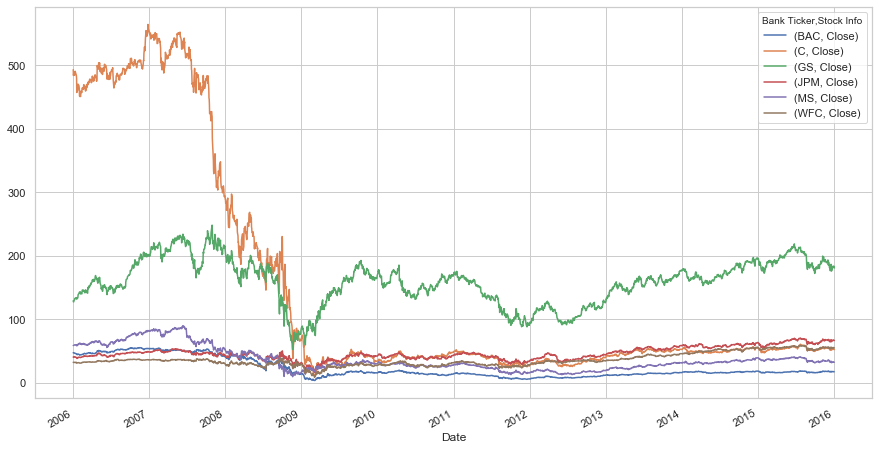

```python
# another solution:
bank_stocks.loc[:,(tickers, slice('Close','Close'))].plot(kind='line',figsize=(15, 8));
```

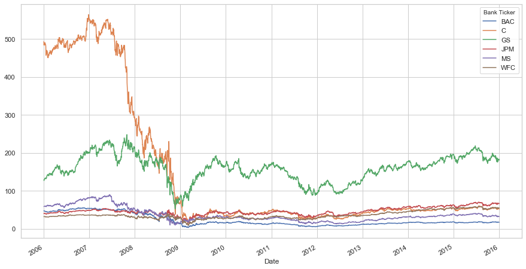

```python
# another solution:
bank_stocks.xs(key='Close',axis=1,level='Stock Info').plot(kind='line',figsize=(15, 8));
```

## Moving Averages

Let's analyze the moving averages for these stocks in the year 2008.

**Plot the rolling 30 day average against the Close Price for Bank Of America's stock for the year 2008**

```python
#from matplotlib.dates import DateFormatter
import matplotlib.dates as mdates
```

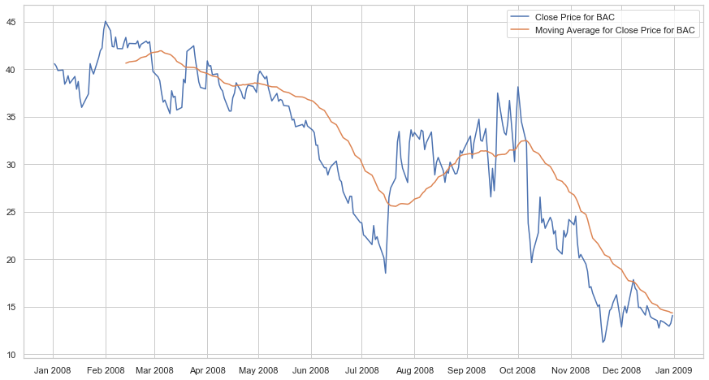

```python
fig, ax = plt.subplots(figsize=(15, 8))
plt.plot(bank_stocks.loc['2008-01-01':'2008-12-31',('BAC', slice('Close','Close'))],label='Close Price for BAC');
plt.plot(bank_stocks.loc['2008-01-01':'2008-12-31',('BAC', slice('Close','Close'))].rolling(window=30).mean()\
         ,label='Moving Average for Close Price for BAC');
plt.legend();
ax.xaxis.set_major_locator(mdates.MonthLocator())
ax.xaxis.set_major_formatter(mdates.DateFormatter("%b %Y"));
```

**Create a heatmap of the correlation between the stocks Close Price.**

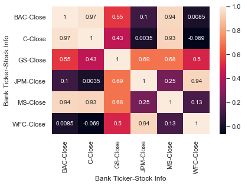

```python
sns.heatmap(bank_stocks.loc[:,(tickers, slice('Close','Close'))].corr(), annot=True);
```

**Optional: Use seaborn's clustermap to cluster the correlations together:**

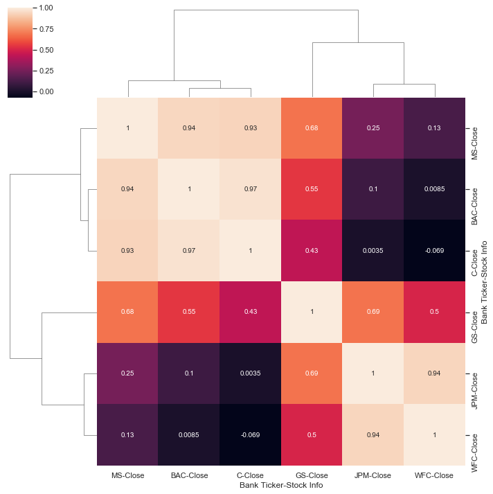

```python
sns.clustermap(bank_stocks.loc[:,(tickers, slice('Close','Close'))].corr(), annot=True);
```

# Part 2 (Optional)

In this second part of the project we will rely on the cufflinks library to create some Technical Analysis plots. This part of the project is experimental due to its heavy reliance on the cuffinks project, so feel free to skip it if any functionality is broken in the future.

**Use .iplot(kind='candle) to create a candle plot of Bank of America's stock from Jan 1st 2015 to Jan 1st 2016.**

```python
#bank_stocks.loc['2015-01-01':'2016-01-01','BAC'].iplot(kind='candle');
```

**Use .ta_plot(study='sma') to create a Simple Moving Averages plot of Morgan Stanley for the year 2015.**

```python
#bank_stocks.loc['2015-01-01':'2016-01-01','MS'].rolling(window=30).mean().ta_plot(study='sma')
```

**Use .ta_plot(study='boll') to create a Bollinger Band Plot for Bank of America for the year 2015.**

```python
#bank_stocks.loc['2015-01-01':'2016-01-01','BAC'].ta_plot(study='boll');
```

# Great Job!

Definitely a lot of more specific finance topics here, so don't worry if you didn't understand them all! The only thing you should be concerned with understanding are the basic pandas and visualization oeprations.